# Exploring Edwards et al 2016 trait data

Daniel Gschwentner

2024-06-20

## Overview

This document contains code to explore and summarize phytoplankton trait from [Edwards et al., 2016.](https://figshare.com/articles/dataset/Data_Paper_Data_Paper/3562857?file=5635515) These data will be used to parameterize lake ecosystem models of phytoplankton competition across TN and TP inflow gradients.

Phytoplankton traits of interest are as follows:

- V~max~ for N and P (maximum uptake rate)
- K~sat~ for N and P (half-saturation constants)
- Q~min~ for N and P (minimum cell quota)
- I~0~ for light (effectively the light half saturation constant)
  - Note that light data is not available here but is presented in Schwaderer et al., 2011. These data will need to be extracted/digitized.
- Cell C volume for conversion of trait parameters
- u~max~ maximum growth rate
  - The u<sub>maxes</sub> listed in this data set are for N- and P-limited conditions. Max growth rates can be pulled from Edwards et al., 2011.

We’re only looking for these parameters for diatoms, cyanobacteria and chlorophytes.

#### Units

The units for traits of interest are listed below:

- C cell<sup>1</sup> content = umol C cell<sup>-1</sup>
- u<sub>max</sub> for N, P limited growth =day<sup>-1</sup>
- K<sub>N,P</sub> for uptake = umol N or P L<sup>-1</sup>
- V<sub>max</sub> for N, P uptake = umol N or P cell<sup>-1</sup> day<sup>-1</sup>
  - Conversion is as follows: (1) multiple with molar weight to get ug N cell<sup>-1</sup> day<sup>-1</sup>; (2) divide by C cell content in ug C cell<sup>-1</sup>; (3) divide by 1,000 to convert ug to mg for models.
- Q<sub>min</sub> and <sub>max</sub> for N, P = umol N or P cell<sup>-1</sup>
  - Conversion is same as for V<sub>max</sub>.

## Data exploration

```r
dim(all.traits)
```

```
## [1] 384  42
```

```r
colnames(all.traits)
```

```
##  [1] "species"     "isolate"     "taxon"       "system"      "temperature"
##  [6] "irradiance"  "light_hours" "synonym"     "volume"      "c_per_cell"
## [11] "c_citation"  "mu_inf_amm"  "mu_amm"      "k_amm_m"     "k_amm"
## [16] "vmax_amm"    "vmax_amm_c"  "qmin_amm"    "qmin_amm_c"  "qmax_amm"
## [21] "qmax_amm_c"  "mu_inf_nit"  "mu_nit"      "k_nit_m"     "k_nit"
## [26] "vmax_nit"    "vmax_nit_c"  "qmin_nit"    "qmin_nit_c"  "qmax_nit"
## [31] "qmax_nit_c"  "mu_inf_p"    "mu_p"        "k_p_m"       "k_p"
## [36] "vmax_p"      "vmax_p_c"    "qmin_p"      "qmin_p_c"    "qmax_p"
## [41] "qmax_p_c"    "citation"
```

```r
head(all.traits)
```

```
## # A tibble: 6 × 42
##   species isolate taxon system temperature irradiance light_hours synonym volume
##   <chr>   <chr>   <chr> <chr>        <dbl>      <dbl>       <dbl> <chr>    <dbl>
## 1 Cyclot… SAG 10… diat… fresh…        20           60          16 <NA>        NA
## 2 Nitzsc… <NA>    diat… marine        20           60          16 <NA>        NA
## 3 Plankt… <NA>    cyano fresh…        24           37          24 <NA>        NA
## 4 Plankt… <NA>    cyano fresh…        15.5         37          NA <NA>        NA
## 5 Plankt… <NA>    cyano fresh…        20.5         37          NA <NA>        NA
## 6 Plankt… <NA>    cyano fresh…        25.5         37          NA <NA>        NA
## # ℹ 33 more variables: c_per_cell <dbl>, c_citation <dbl>, mu_inf_amm <dbl>,
## #   mu_amm <dbl>, k_amm_m <dbl>, k_amm <dbl>, vmax_amm <dbl>, vmax_amm_c <dbl>,
## #   qmin_amm <dbl>, qmin_amm_c <dbl>, qmax_amm <dbl>, qmax_amm_c <lgl>,
## #   mu_inf_nit <dbl>, mu_nit <dbl>, k_nit_m <dbl>, k_nit <dbl>, vmax_nit <dbl>,
## #   vmax_nit_c <dbl>, qmin_nit <dbl>, qmin_nit_c <dbl>, qmax_nit <dbl>,
## #   qmax_nit_c <dbl>, mu_inf_p <dbl>, mu_p <dbl>, k_p_m <dbl>, k_p <dbl>,
## #   vmax_p <dbl>, vmax_p_c <dbl>, qmin_p <dbl>, qmin_p_c <dbl>, qmax_p <dbl>, …
```

#### Data structure notes

384 observations of 42 variables; variables of interest are as follows:

- species, taxon, system
- c_per_cell
- k_nit, vmax_nit, qmin_nit, qmax_nit
- k_p, vmax_p, qmin_p, qmax_p
- mu_nit, mu_p

```r
unique(all.traits$system)
```

```
## [1] "freshwater" "marine"     "fresh"
```

```r
all.traits$system <- ifelse(all.traits$system == "fresh", "freshwater", all.traits$system)
unique(all.traits$taxon)
```

```
##  [1] "diatom"        "cyano"         "green"         "haptophyte"
##  [5] "dino"          "euglenoid"     "raphidophyte"  "cocco"
##  [9] "cryptomonad"   "desmid"        "chrysophyceae" "pelagophyte"
## [13] "xanthophyte"
```

```r
table(all.traits$system)
```

```
##
## freshwater     marine
##        211        173
```

```r
table(all.traits$taxon)
```

```
##
## chrysophyceae         cocco   cryptomonad         cyano        desmid
##             1             3             1            47             8
##        diatom          dino     euglenoid         green    haptophyte
##           134            28             1           120            29
##   pelagophyte  raphidophyte   xanthophyte
##             2             8             2
```

```r
table(all.traits$system, all.traits$taxon)
```

```
##
##              chrysophyceae cocco cryptomonad cyano desmid diatom dino euglenoid
##   freshwater             1     0           1    40      8     57    0         1
##   marine                 0     3           0     7      0     77   28         0
##
##              green haptophyte pelagophyte raphidophyte xanthophyte
##   freshwater   101          0           0            0           2
##   marine        19         29           2            8           0
```

There are 211 entries for freshwater systems and 173 for marine. The majority of entries are for diatoms (n = 134), green algae (n = 120), and cyanobacteria (n = 47). Breaking down these data by system and taxon shows that there are more observations for green algae in freshwater systems (n~fresh} = 101, n~marine~ = 19) and for cyanobacteria (n~fresh~ = 40, n~marine~ = 7) but not for diatoms (n~fresh~ = 57, n~marine~ = 77).

#### Subset data

Subset data to only include green algae, diatoms, cyanobacteria and select traits listed above. Will keep both marine and freshwater phytoplankton for now as Edwards et al., 2011 and Litchmann et al., 2007 review papers suggest that there is not that much difference between traits of freshwater and marine species, particularly once they have been normalized to cell volume.

```r
selected.traits <- all.traits %>%
  filter(taxon %in% c("green", "diatom", "cyano")) %>%
  select(species, taxon, system, c_per_cell, k_nit, vmax_nit, qmin_nit, qmax_nit,
         k_p, vmax_p, qmin_p, qmax_p, mu_nit, mu_p)
```

```r
# nr and percent of observations with data for each parameter
apply(selected.traits, 2, function(x) sum(!is.na(x)))
```

```
##    species      taxon     system c_per_cell      k_nit   vmax_nit   qmin_nit
##        301        301        301          9         66         61         48
##   qmax_nit        k_p     vmax_p     qmin_p     qmax_p     mu_nit       mu_p
##         17        113        115        117         38         38         89
```

```r
apply(selected.traits, 2, function(x) sum(!is.na(x))) * 100/nrow(selected.traits)
```

```
##    species      taxon     system c_per_cell      k_nit   vmax_nit   qmin_nit
## 100.000000 100.000000 100.000000   2.990033  21.926910  20.265781  15.946844
##   qmax_nit        k_p     vmax_p     qmin_p     qmax_p     mu_nit       mu_p
##   5.647841  37.541528  38.205980  38.870432  12.624585  12.624585  29.568106
```

```r
selected.traits %>%
  select(-species) %>%
  gather("trait", "trait.value", -system, -taxon) %>%
  group_by(system, taxon, trait) %>%
  mutate(not.na = !is.na(trait.value)) %>%
  summarise(nr.obs = sum(not.na)) %>%
  mutate(perc.obs = round(nr.obs * 100/nrow(selected.traits), 2)) %>%
  pivot_wider(id_cols = c(taxon, trait),
              names_from = system,
              values_from = nr.obs) %>%
  knitr::kable()
```

| taxon | trait | freshwater | marine |
| --- | --- | --- | --- |
| cyano | c_per_cell | 2 | 2 |
| cyano | k_nit | 6 | 0 |
| cyano | k_p | 17 | 5 |
| cyano | mu_nit | 5 | 1 |
| cyano | mu_p | 16 | 4 |
| cyano | qmax_nit | 2 | 0 |
| cyano | qmax_p | 10 | 5 |
| cyano | qmin_nit | 4 | 1 |
| cyano | qmin_p | 17 | 5 |
| cyano | vmax_nit | 6 | 0 |
| cyano | vmax_p | 16 | 5 |
| diatom | c_per_cell | 0 | 3 |
| diatom | k_nit | 8 | 20 |
| diatom | k_p | 25 | 13 |
| diatom | mu_nit | 1 | 19 |
| diatom | mu_p | 25 | 11 |
| diatom | qmax_nit | 3 | 2 |
| diatom | qmax_p | 3 | 5 |
| diatom | qmin_nit | 5 | 18 |
| diatom | qmin_p | 33 | 26 |
| diatom | vmax_nit | 8 | 15 |
| diatom | vmax_p | 25 | 15 |
| green | c_per_cell | 1 | 1 |
| green | k_nit | 30 | 2 |
| green | k_p | 50 | 3 |
| green | mu_nit | 3 | 9 |
| green | mu_p | 31 | 2 |
| green | qmax_nit | 9 | 1 |
| green | qmax_p | 15 | 0 |
| green | qmin_nit | 17 | 3 |
| green | qmin_p | 33 | 3 |
| green | vmax_nit | 30 | 2 |
| green | vmax_p | 51 | 3 |

## Summary of phytoplankton traits

```r
selected.traits %>%
  select(-species) %>%
  gather("trait", "trait.value", -system, -taxon) %>%
  ggplot(aes(trait.value, fill = taxon), alpha = 0.3) +
  geom_density() +
  ggh4x::facet_grid2(system~trait, scales = "free", independent = "all") +
  labs(x = "Trait value", y = "Density", fill = NULL) +
  theme(legend.position = "bottom")
```

[figure not shown]

### Differences in phytoplankton traits by system

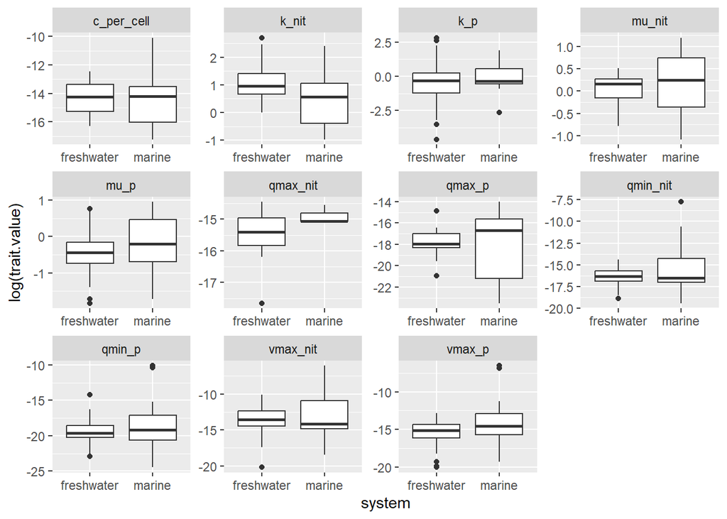

```r
selected.traits %>%
  select(-species) %>%
  gather("trait", "trait.value", -system, -taxon) %>%
  ggplot(aes(system, log(trait.value))) +
  geom_boxplot() +
  facet_wrap(trait~.,scales = "free")
```

### Create summary table of phytoplankton traits

```r
selected.traits %>%
  select(-species) %>%
  gather("trait", "trait.value", -system, -taxon) %>%
  group_by(system, taxon, trait) %>%
  summarise(min = min(trait.value, na.rm = T),
            mean = mean(trait.value, na.rm = T),
            median = median(trait.value, na.rm = T),
            max = max(trait.value, na.rm = T),
            sd = sd(trait.value, na.rm = T),
            n = n()) %>%
  knitr::kable()
```

| system | taxon | trait | min | mean | median | max | sd | n |
| --- | --- | --- | --- | --- | --- | --- | --- | --- |
| freshwater | cyano | c_per_cell | 1.00e-07 | 0.0000004 | 0.0000004 | 7.000e-07 | 0.0000004 | 40 |
| freshwater | cyano | k_nit | 1.48e+00 | 2.6283333 | 2.3600000 | 4.200e+00 | 1.0737675 | 40 |
| freshwater | cyano | k_p | 1.00e-02 | 1.1227941 | 0.8500000 | 3.450e+00 | 1.0766099 | 40 |
| freshwater | cyano | mu_nit | 4.60e-01 | 0.9220000 | 0.8600000 | 1.440e+00 | 0.3923264 | 40 |
| freshwater | cyano | mu_p | 1.80e-01 | 0.7368750 | 0.6550000 | 1.680e+00 | 0.3961602 | 40 |
| freshwater | cyano | qmax_nit | 0.00e+00 | 0.0000001 | 0.0000001 | 1.000e-07 | 0.0000001 | 40 |
| freshwater | cyano | qmax_p | 0.00e+00 | 0.0000000 | 0.0000000 | 0.000e+00 | 0.0000000 | 40 |
| freshwater | cyano | qmin_nit | 0.00e+00 | 0.0000001 | 0.0000000 | 2.000e-07 | 0.0000001 | 40 |
| freshwater | cyano | qmin_p | 0.00e+00 | 0.0000000 | 0.0000000 | 0.000e+00 | 0.0000000 | 40 |
| freshwater | cyano | vmax_nit | 0.00e+00 | 0.0000001 | 0.0000001 | 2.000e-07 | 0.0000001 | 40 |
| freshwater | cyano | vmax_p | 0.00e+00 | 0.0000003 | 0.0000002 | 1.200e-06 | 0.0000003 | 40 |
| freshwater | diatom | c_per_cell | Inf | NaN | NA | -Inf | NA | 57 |
| freshwater | diatom | k_nit | 1.31e+00 | 5.5262500 | 4.5800000 | 1.490e+01 | 4.3155829 | 57 |
| freshwater | diatom | k_p | 1.00e-02 | 1.0748000 | 0.1600000 | 1.345e+01 | 2.6923907 | 57 |
| freshwater | diatom | mu_nit | 8.60e-01 | 0.8600000 | 0.8600000 | 8.600e-01 | NA | 57 |
| freshwater | diatom | mu_p | 3.00e-01 | 0.6168000 | 0.6100000 | 1.000e+00 | 0.1709708 | 57 |
| freshwater | diatom | qmax_nit | 1.00e-07 | 0.0000003 | 0.0000002 | 5.000e-07 | 0.0000002 | 57 |
| freshwater | diatom | qmax_p | 0.00e+00 | 0.0000001 | 0.0000001 | 1.000e-07 | 0.0000000 | 57 |
| freshwater | diatom | qmin_nit | 0.00e+00 | 0.0000003 | 0.0000002 | 6.000e-07 | 0.0000003 | 57 |
| freshwater | diatom | qmin_p | 0.00e+00 | 0.0000000 | 0.0000000 | 7.000e-07 | 0.0000001 | 57 |
| freshwater | diatom | vmax_nit | 8.00e-07 | 0.0000040 | 0.0000046 | 6.200e-06 | 0.0000022 | 57 |
| freshwater | diatom | vmax_p | 0.00e+00 | 0.0000003 | 0.0000003 | 2.000e-06 | 0.0000004 | 57 |
| freshwater | green | c_per_cell | 3.90e-06 | 0.0000039 | 0.0000039 | 3.900e-06 | NA | 101 |
| freshwater | green | k_nit | 1.00e+00 | 3.2536667 | 2.5350000 | 1.162e+01 | 2.3536347 | 101 |
| freshwater | green | k_p | 1.60e-01 | 1.8137200 | 0.9200000 | 1.666e+01 | 3.1443785 | 101 |
| freshwater | green | mu_nit | 1.23e+00 | 1.4100000 | 1.3200000 | 1.680e+00 | 0.2381176 | 101 |
| freshwater | green | mu_p | 0.00e+00 | 0.7723226 | 0.6300000 | 2.140e+00 | 0.5750161 | 101 |
| freshwater | green | qmax_nit | 1.00e-07 | 0.0000002 | 0.0000002 | 4.000e-07 | 0.0000001 | 101 |
| freshwater | green | qmax_p | 0.00e+00 | 0.0000001 | 0.0000000 | 4.000e-07 | 0.0000001 | 101 |
| freshwater | green | qmin_nit | 0.00e+00 | 0.0000001 | 0.0000001 | 2.000e-07 | 0.0000001 | 101 |
| freshwater | green | qmin_p | 0.00e+00 | 0.0000000 | 0.0000000 | 1.000e-07 | 0.0000000 | 101 |
| freshwater | green | vmax_nit | 2.00e-07 | 0.0000036 | 0.0000014 | 3.950e-05 | 0.0000072 | 101 |
| freshwater | green | vmax_p | 0.00e+00 | 0.0000006 | 0.0000004 | 2.700e-06 | 0.0000006 | 101 |
| marine | cyano | c_per_cell | 0.00e+00 | 0.0000001 | 0.0000001 | 1.000e-07 | 0.0000000 | 7 |
| marine | cyano | k_nit | Inf | NaN | NA | -Inf | NA | 7 |
| marine | cyano | k_p | 7.00e-02 | 0.4560000 | 0.4200000 | 7.500e-01 | 0.2615913 | 7 |
| marine | cyano | mu_nit | 2.16e+00 | 2.1600000 | 2.1600000 | 2.160e+00 | NA | 7 |
| marine | cyano | mu_p | 1.80e-01 | 0.4025000 | 0.3750000 | 6.800e-01 | 0.2304163 | 7 |
| marine | cyano | qmax_nit | Inf | NaN | NA | -Inf | NA | 7 |
| marine | cyano | qmax_p | 0.00e+00 | 0.0000000 | 0.0000000 | 1.000e-07 | 0.0000000 | 7 |
| marine | cyano | qmin_nit | 0.00e+00 | 0.0000000 | 0.0000000 | 0.000e+00 | NA | 7 |
| marine | cyano | qmin_p | 0.00e+00 | 0.0000000 | 0.0000000 | 0.000e+00 | 0.0000000 | 7 |
| marine | cyano | vmax_nit | Inf | NaN | NA | -Inf | NA | 7 |
| marine | cyano | vmax_p | 0.00e+00 | 0.0000001 | 0.0000000 | 2.000e-07 | 0.0000001 | 7 |
| marine | diatom | c_per_cell | 4.00e-07 | 0.0000144 | 0.0000012 | 4.170e-05 | 0.0000236 | 77 |
| marine | diatom | k_nit | 3.80e-01 | 1.9111450 | 1.7550000 | 5.080e+00 | 1.3624169 | 77 |
| marine | diatom | k_p | 4.70e-01 | 2.1007692 | 1.4000000 | 6.670e+00 | 2.1494281 | 77 |
| marine | diatom | mu_nit | 3.40e-01 | 1.2721053 | 0.8300000 | 3.310e+00 | 0.9587178 | 77 |
| marine | diatom | mu_p | 3.20e-01 | 1.1918182 | 1.3000000 | 2.600e+00 | 0.6745638 | 77 |
| marine | diatom | qmax_nit | 3.00e-07 | 0.0000003 | 0.0000003 | 3.000e-07 | 0.0000000 | 77 |
| marine | diatom | qmax_p | 0.00e+00 | 0.0000003 | 0.0000002 | 8.000e-07 | 0.0000003 | 77 |
| marine | diatom | qmin_nit | 0.00e+00 | 0.0000505 | 0.0000001 | 4.400e-04 | 0.0001418 | 77 |
| marine | diatom | qmin_p | 0.00e+00 | 0.0000027 | 0.0000000 | 4.000e-05 | 0.0000096 | 77 |
| marine | diatom | vmax_nit | 1.00e-07 | 0.0002514 | 0.0000015 | 2.290e-03 | 0.0006685 | 77 |
| marine | diatom | vmax_p | 0.00e+00 | 0.0001655 | 0.0000009 | 1.440e-03 | 0.0004378 | 77 |
| marine | green | c_per_cell | 1.40e-06 | 0.0000014 | 0.0000014 | 1.400e-06 | NA | 19 |
| marine | green | k_nit | 4.70e-01 | 5.7850000 | 5.7850000 | 1.110e+01 | 7.5165451 | 19 |
| marine | green | k_p | 6.80e-01 | 1.0300000 | 0.6900000 | 1.720e+00 | 0.5975784 | 19 |
| marine | green | mu_nit | 1.08e+00 | 1.6022222 | 1.3400000 | 2.400e+00 | 0.4988180 | 19 |
| marine | green | mu_p | 8.20e-01 | 1.3050000 | 1.3050000 | 1.790e+00 | 0.6858936 | 19 |
| marine | green | qmax_nit | 5.00e-07 | 0.0000005 | 0.0000005 | 5.000e-07 | NA | 19 |
| marine | green | qmax_p | Inf | NaN | NA | -Inf | NA | 19 |
| marine | green | qmin_nit | 0.00e+00 | 0.0000001 | 0.0000001 | 1.000e-07 | 0.0000000 | 19 |
| marine | green | qmin_p | 0.00e+00 | 0.0000000 | 0.0000000 | 0.000e+00 | 0.0000000 | 19 |
| marine | green | vmax_nit | 0.00e+00 | 0.0000002 | 0.0000002 | 4.000e-07 | 0.0000003 | 19 |
| marine | green | vmax_p | 1.00e-07 | 0.0000010 | 0.0000012 | 1.700e-06 | 0.0000008 | 19 |

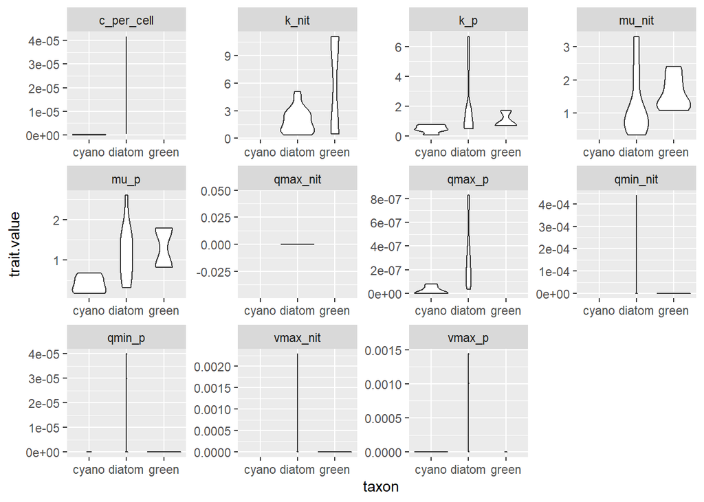

```r
selected.traits %>%
  select(-species) %>%
  gather("trait", "trait.value", -system, -taxon) %>%
  filter(system == "marine") %>%
  ggplot(aes(taxon, trait.value)) +
  geom_violin() +
  facet_wrap(trait~.,scales = "free")
```

## Taxon-specific trait values

Here I summarize the taxon-specific trait values and provide average values to parameterize models.

```r
cust.sum <- function(x){
  x <- x[!is.na(x)]
  x.mean = mean(x); x.median = median(x); x.min = min(x); x.max = max(x); x.sd = sd(x); x.n = length(x);
  x <- list(
    mean = x.mean,
    median = x.median,
    min = x.min,
    max = x.max,
    sd = x.sd,
    var = x.mean/x.sd * 100,
    n = x.n
  )
  return(x)
}

# conversion function
mole2mass <- function(x, y){
  return(x * y)
}


# quick reminder of traits
colnames(selected.traits)
```

```
##  [1] "species"    "taxon"      "system"     "c_per_cell" "k_nit"
##  [6] "vmax_nit"   "qmin_nit"   "qmax_nit"   "k_p"        "vmax_p"
## [11] "qmin_p"     "qmax_p"     "mu_nit"     "mu_p"
```

### Diatoms

```r
diatoms <- selected.traits[selected.traits$taxon == "diatom" & selected.traits$system == "freshwater",]
#summary(diatoms)
(diatoms.traits <- diatoms %>%
  select(-species, -taxon, -system) %>%
  gather("Trait", "trait.value") %>%
  drop_na() %>%
  group_by(Trait) %>%
  summarise(
    Mean = mean(trait.value, na.rm = T),
    Median = median(trait.value, na.rm = T),
    Min = min(trait.value, na.rm = T),
    Max = max(trait.value, na.rm = T),
    sd = sd(trait.value, na.rm = T),
    std.err = sd(trait.value, na.rm = T)/sqrt(n()),
    n = n()
  )) %>%
  knitr::kable()
```

| Trait | Mean | Median | Min | Max | sd | std.err | n |
| --- | --- | --- | --- | --- | --- | --- | --- |
| k_nit | 5.5262500 | 4.58e+00 | 1.31e+00 | 1.490e+01 | 4.3155829 | 1.5257889 | 8 |
| k_p | 1.0748000 | 1.60e-01 | 1.00e-02 | 1.345e+01 | 2.6923907 | 0.5384781 | 25 |
| mu_nit | 0.8600000 | 8.60e-01 | 8.60e-01 | 8.600e-01 | NA | NA | 1 |
| mu_p | 0.6168000 | 6.10e-01 | 3.00e-01 | 1.000e+00 | 0.1709708 | 0.0341942 | 25 |
| qmax_nit | 0.0000003 | 2.00e-07 | 1.00e-07 | 5.000e-07 | 0.0000002 | 0.0000001 | 3 |
| qmax_p | 0.0000001 | 1.00e-07 | 0.00e+00 | 1.000e-07 | 0.0000000 | 0.0000000 | 3 |
| qmin_nit | 0.0000003 | 2.00e-07 | 0.00e+00 | 6.000e-07 | 0.0000003 | 0.0000001 | 5 |
| qmin_p | 0.0000000 | 0.00e+00 | 0.00e+00 | 7.000e-07 | 0.0000001 | 0.0000000 | 33 |
| vmax_nit | 0.0000040 | 4.60e-06 | 8.00e-07 | 6.200e-06 | 0.0000022 | 0.0000008 | 8 |
| vmax_p | 0.0000003 | 3.00e-07 | 0.00e+00 | 2.000e-06 | 0.0000004 | 0.0000001 | 25 |

#### Diatom unit conversions

```r
# DIY conversions
diatoms.traits.mass.units <- diatoms %>%
   mutate(cell_C_mg = c_per_cell * 12.011/1000,
          K_P_mgL = k_p * 30.974/1000,
          K_N_mgL = k_nit*14.007/1000)
# for Vmax, Qmax use the median C content for conversion
### for diatoms, this will be median of marine C content!
median.C.marine.diatoms <- selected.traits %>% filter(taxon == "diatom") %>%
  mutate(cell_C_mg = c_per_cell * 12.011/1000)
median.C.marine.diatoms <- median(median.C.marine.diatoms$cell_C_mg, na.rm = T)
#median.C.marine.diatoms
# conversions pt 2
diatoms.traits.mass.units <- diatoms.traits.mass.units %>%
  mutate(Qmax_mg_N_mg_C = qmax_nit * 14.007/median.C.marine.diatoms/1000,
         Qmax_mg_P_mg_C = qmax_p * 30.974/median.C.marine.diatoms/1000,
         Qmin_mg_N_mg_C = qmin_nit * 14.007/median.C.marine.diatoms/1000,
         Qmin_mg_P_mg_C = qmin_p * 30.974/median.C.marine.diatoms/1000,
         Vmax_mg_N_mg_C = vmax_nit* 14.007/median.C.marine.diatoms/1000,
         Vmax_mg_P_mg_C = vmax_p * 30.974/median.C.marine.diatoms/1000,
         umax_N = mu_nit,
         umax_P = mu_p)

# summary
(diatoms.traits.mass <- diatoms.traits.mass.units %>%
  select(K_P_mgL, K_N_mgL, Qmax_mg_N_mg_C, Qmax_mg_P_mg_C, Qmin_mg_N_mg_C, Qmin_mg_P_mg_C, Vmax_mg_N_mg_C, Vmax_mg_P_mg_C, umax_N, umax_P) %>%
  gather("Trait", "trait.value") %>%
  drop_na() %>%
  group_by(Trait) %>%
  summarise(
    Mean = mean(trait.value, na.rm = T),
    Median = median(trait.value, na.rm = T),
    Min = min(trait.value, na.rm = T),
    Max = max(trait.value, na.rm = T),
    sd = sd(trait.value, na.rm = T),
    std.err = sd(trait.value, na.rm = T)/sqrt(n()),
    q25 = quantile(trait.value, 0.25, na.rm = T),
    q75 = quantile(trait.value, 0.75, na.rm = T),
    n = n()
  ) %>% mutate(taxon = "diatoms")) %>%
  knitr::kable()
```

| Trait | Mean | Median | Min | Max | sd | std.err | q25 | q75 | n | taxon |
| --- | --- | --- | --- | --- | --- | --- | --- | --- | --- | --- |
| K_N_mgL | 0.0774062 | 0.0641521 | 0.0183492 | 0.2087043 | 0.0604484 | 0.0213717 | 0.0383091 | 0.0866333 | 8 | diatoms |
| K_P_mgL | 0.0332909 | 0.0049558 | 0.0003097 | 0.4166003 | 0.0833941 | 0.0166788 | 0.0018584 | 0.0244695 | 25 | diatoms |
| Qmax_mg_N_mg_C | 0.2860383 | 0.2011662 | 0.1418854 | 0.5150633 | 0.2005440 | 0.1157841 | 0.1715258 | 0.3581147 | 3 | diatoms |
| Qmax_mg_P_mg_C | 0.1181235 | 0.1461322 | 0.0507165 | 0.1575219 | 0.0586533 | 0.0338635 | 0.0984243 | 0.1518270 | 3 | diatoms |
| Qmin_mg_N_mg_C | 0.2629738 | 0.1554908 | 0.0447036 | 0.5539360 | 0.2434801 | 0.1088876 | 0.0651118 | 0.4956269 | 5 | diatoms |
| Qmin_mg_P_mg_C | 0.0805694 | 0.0195559 | 0.0036533 | 1.4871096 | 0.2568434 | 0.0447107 | 0.0083811 | 0.0446992 | 33 | diatoms |
| Vmax_mg_N_mg_C | 3.8797384 | 4.4897969 | 0.7755104 | 6.0447049 | 2.1345857 | 0.7546900 | 2.1307099 | 5.6535483 | 8 | diatoms |
| Vmax_mg_P_mg_C | 0.7449474 | 0.6081677 | 0.0904730 | 4.2980046 | 0.8505942 | 0.1701188 | 0.2112469 | 0.9283690 | 25 | diatoms |
| umax_N | 0.8600000 | 0.8600000 | 0.8600000 | 0.8600000 | NA | NA | 0.8600000 | 0.8600000 | 1 | diatoms |
| umax_P | 0.6168000 | 0.6100000 | 0.3000000 | 1.0000000 | 0.1709708 | 0.0341942 | 0.5200000 | 0.7300000 | 25 | diatoms |

### Green algae

```r
greens <- selected.traits[selected.traits$taxon == "green" & selected.traits$system == "freshwater",]
#summary(greens)
(greens.traits <- greens %>%
  select(-species, -taxon, -system) %>%
  gather("Trait", "trait.value") %>%
  drop_na() %>%
  group_by(Trait) %>%
  summarise(
    Mean = mean(trait.value, na.rm = T),
    Median = median(trait.value, na.rm = T),
    Min = min(trait.value, na.rm = T),
    Max = max(trait.value, na.rm = T),
    sd = sd(trait.value, na.rm = T),
    std.err = sd(trait.value, na.rm = T)/sqrt(n()),
    n = n()
  )) %>%
  knitr::kable()
```

| Trait | Mean | Median | Min | Max | sd | std.err | n |
| --- | --- | --- | --- | --- | --- | --- | --- |
| c_per_cell | 0.0000039 | 0.0000039 | 3.90e-06 | 3.900e-06 | NA | NA | 1 |
| k_nit | 3.2536667 | 2.5350000 | 1.00e+00 | 1.162e+01 | 2.3536347 | 0.4297129 | 30 |
| k_p | 1.8137200 | 0.9200000 | 1.60e-01 | 1.666e+01 | 3.1443785 | 0.4446823 | 50 |
| mu_nit | 1.4100000 | 1.3200000 | 1.23e+00 | 1.680e+00 | 0.2381176 | 0.1374773 | 3 |
| mu_p | 0.7723226 | 0.6300000 | 0.00e+00 | 2.140e+00 | 0.5750161 | 0.1032759 | 31 |
| qmax_nit | 0.0000002 | 0.0000002 | 1.00e-07 | 4.000e-07 | 0.0000001 | 0.0000000 | 9 |
| qmax_p | 0.0000001 | 0.0000000 | 0.00e+00 | 4.000e-07 | 0.0000001 | 0.0000000 | 15 |
| qmin_nit | 0.0000001 | 0.0000001 | 0.00e+00 | 2.000e-07 | 0.0000001 | 0.0000000 | 17 |
| qmin_p | 0.0000000 | 0.0000000 | 0.00e+00 | 1.000e-07 | 0.0000000 | 0.0000000 | 33 |
| vmax_nit | 0.0000036 | 0.0000014 | 2.00e-07 | 3.950e-05 | 0.0000072 | 0.0000013 | 30 |
| vmax_p | 0.0000006 | 0.0000004 | 0.00e+00 | 2.700e-06 | 0.0000006 | 0.0000001 | 51 |

#### Green algae unit conversions

```r
# DIY conversions
greens.traits.mass.units <- greens %>%
   mutate(cell_C_mg = c_per_cell * 12.011/1000,
          K_P_mgL = k_p * 30.974/1000,
          K_N_mgL = k_nit*14.007/1000)
# for Vmax, Qmax use the median C content for conversion
### for diatoms, this will be median of marine C content!
median.C.greens <- median(greens.traits.mass.units$cell_C_mg, na.rm = T)
median.C.greens
```

```
## [1] 4.68429e-08
```

```r
# conversions pt 2
greens.traits.mass.units <- greens.traits.mass.units %>%
  mutate(Qmax_mg_N_mg_C = qmax_nit * 14.007/median.C.greens/1000,
         Qmax_mg_P_mg_C = qmax_p * 30.974/median.C.greens/1000,
         Qmin_mg_N_mg_C = qmin_nit * 14.007/median.C.greens/1000,
         Qmin_mg_P_mg_C = qmin_p * 30.974/median.C.greens/1000,
         Vmax_mg_N_mg_C = vmax_nit* 14.007/median.C.greens/1000,
         Vmax_mg_P_mg_C = vmax_p * 30.974/median.C.greens/1000,
         umax_N = mu_nit,
         umax_P = mu_p)

# summary
(greens.traits.mass <- greens.traits.mass.units %>%
  select(K_P_mgL, K_N_mgL, Qmax_mg_N_mg_C, Qmax_mg_P_mg_C, Qmin_mg_N_mg_C, Qmin_mg_P_mg_C, Vmax_mg_N_mg_C, Vmax_mg_P_mg_C, umax_N, umax_P) %>%
  gather("Trait", "trait.value") %>%
  drop_na() %>%
  group_by(Trait) %>%
  summarise(
    Mean = mean(trait.value, na.rm = T),
    Median = median(trait.value, na.rm = T),
    Min = min(trait.value, na.rm = T),
    Max = max(trait.value, na.rm = T),
    sd = sd(trait.value, na.rm = T),
    std.err = sd(trait.value, na.rm = T)/sqrt(n()),
    q25 = quantile(trait.value, 0.25, na.rm = T),
    q75 = quantile(trait.value, 0.75, na.rm = T),
    n = n()
  ) %>% mutate(taxon = "greens")) %>%
  knitr::kable()
```

| Trait | Mean | Median | Min | Max | sd | std.err | q25 | q75 | n | taxon |
| --- | --- | --- | --- | --- | --- | --- | --- | --- | --- | --- |
| K_N_mgL | 0.0455741 | 0.0355077 | 0.0140070 | 0.1627613 | 0.0329674 | 0.0060190 | 0.0258079 | 0.0558879 | 30 | greens |
| K_P_mgL | 0.0561782 | 0.0284961 | 0.0049558 | 0.5160268 | 0.0973940 | 0.0137736 | 0.0181198 | 0.0417375 | 50 | greens |
| Qmax_mg_N_mg_C | 0.0733930 | 0.0675787 | 0.0278089 | 0.1166181 | 0.0318647 | 0.0106216 | 0.0562159 | 0.1022651 | 9 | greens |
| Qmax_mg_P_mg_C | 0.0338960 | 0.0148116 | 0.0043641 | 0.2353984 | 0.0577883 | 0.0149209 | 0.0076042 | 0.0341857 | 15 | greens |
| Qmin_mg_N_mg_C | 0.0275504 | 0.0251177 | 0.0035882 | 0.0627944 | 0.0170305 | 0.0041305 | 0.0137550 | 0.0373776 | 17 | greens |
| Qmin_mg_P_mg_C | 0.0044156 | 0.0013886 | 0.0001455 | 0.0528985 | 0.0099742 | 0.0017363 | 0.0010580 | 0.0023341 | 33 | greens |
| Vmax_mg_N_mg_C | 1.0621517 | 0.4156389 | 0.0580100 | 11.8113204 | 2.1461742 | 0.3918360 | 0.1705166 | 0.9785455 | 30 | greens |
| Vmax_mg_P_mg_C | 0.3734140 | 0.2433332 | 0.0015870 | 1.8117742 | 0.4004608 | 0.0560757 | 0.0773641 | 0.5508058 | 51 | greens |
| umax_N | 1.4100000 | 1.3200000 | 1.2300000 | 1.6800000 | 0.2381176 | 0.1374773 | 1.2750000 | 1.5000000 | 3 | greens |
| umax_P | 0.7723226 | 0.6300000 | 0.0000000 | 2.1400000 | 0.5750161 | 0.1032759 | 0.4050000 | 1.0000000 | 31 | greens |

### Cyanobacteria

```r
cyanos <- selected.traits[selected.traits$taxon == "cyano" & selected.traits$system == "freshwater",]
#summary(cyanos)
(cyanos.traits <- cyanos %>%
  select(-species, -taxon, -system) %>%
  gather("Trait", "trait.value") %>%
  drop_na() %>%
  group_by(Trait) %>%
  summarise(
    Mean = mean(trait.value, na.rm = T),
    Median = median(trait.value, na.rm = T),
    Min = min(trait.value, na.rm = T),
    Max = max(trait.value, na.rm = T),
    sd = sd(trait.value, na.rm = T),
    std.err = sd(trait.value, na.rm = T)/sqrt(n()),
    q25 = quantile(trait.value, 0.25, na.rm = T),
    q75 = quantile(trait.value, 0.75, na.rm = T),
    n = n()
  )) %>%
  knitr::kable()
```

| Trait | Mean | Median | Min | Max | sd | std.err | q25 | q75 | n |
| --- | --- | --- | --- | --- | --- | --- | --- | --- | --- |
| c_per_cell | 0.0000004 | 4.00e-07 | 1.00e-07 | 7.00e-07 | 0.0000004 | 0.0000003 | 2.00e-07 | 0.0000005 | 2 |
| k_nit | 2.6283333 | 2.36e+00 | 1.48e+00 | 4.20e+00 | 1.0737675 | 0.4383638 | 1.85e+00 | 3.3575000 | 6 |
| k_p | 1.1227941 | 8.50e-01 | 1.00e-02 | 3.45e+00 | 1.0766099 | 0.2611163 | 4.70e-01 | 1.4500000 | 17 |
| mu_nit | 0.9220000 | 8.60e-01 | 4.60e-01 | 1.44e+00 | 0.3923264 | 0.1754537 | 6.70e-01 | 1.1800000 | 5 |
| mu_p | 0.7368750 | 6.55e-01 | 1.80e-01 | 1.68e+00 | 0.3961602 | 0.0990401 | 5.25e-01 | 0.8675000 | 16 |
| qmax_nit | 0.0000001 | 1.00e-07 | 0.00e+00 | 1.00e-07 | 0.0000001 | 0.0000001 | 0.00e+00 | 0.0000001 | 2 |
| qmax_p | 0.0000000 | 0.00e+00 | 0.00e+00 | 0.00e+00 | 0.0000000 | 0.0000000 | 0.00e+00 | 0.0000000 | 10 |
| qmin_nit | 0.0000001 | 0.00e+00 | 0.00e+00 | 2.00e-07 | 0.0000001 | 0.0000000 | 0.00e+00 | 0.0000001 | 4 |
| qmin_p | 0.0000000 | 0.00e+00 | 0.00e+00 | 0.00e+00 | 0.0000000 | 0.0000000 | 0.00e+00 | 0.0000000 | 17 |
| vmax_nit | 0.0000001 | 1.00e-07 | 0.00e+00 | 2.00e-07 | 0.0000001 | 0.0000000 | 0.00e+00 | 0.0000002 | 6 |
| vmax_p | 0.0000003 | 2.00e-07 | 0.00e+00 | 1.20e-06 | 0.0000003 | 0.0000001 | 1.00e-07 | 0.0000003 | 16 |

#### Cyanobacteria unit conversions

```r
# DIY conversions
cyanos.traits.mass.units <- cyanos %>%
   mutate(cell_C_mg = c_per_cell * 12.011/1000,
          K_P_mgL = k_p * 30.974/1000,
          K_N_mgL = k_nit*14.007/1000)
# for Vmax, Qmax use the median C content for conversion
### for diatoms, this will be median of marine C content!
median.C.cyanos <- median(cyanos.traits.mass.units$cell_C_mg, na.rm = T)
median.C.cyanos
```

```
## [1] 4.402031e-09
```

```r
# conversions pt 2
cyanos.traits.mass.units <- cyanos.traits.mass.units %>%
  mutate(Qmax_mg_N_mg_C = qmax_nit * 14.007/median.C.greens/1000,
         Qmax_mg_P_mg_C = qmax_p * 30.974/median.C.greens/1000,
         Qmin_mg_N_mg_C = qmin_nit * 14.007/median.C.greens/1000,
         Qmin_mg_P_mg_C = qmin_p * 30.974/median.C.greens/1000,
         Vmax_mg_N_mg_C = vmax_nit* 14.007/median.C.greens/1000,
         Vmax_mg_P_mg_C = vmax_p * 30.974/median.C.greens/1000,
         umax_N = mu_nit,
         umax_P = mu_p)

# summary
(cyanos.traits.mass <- cyanos.traits.mass.units %>%
  select(K_P_mgL, K_N_mgL, Qmax_mg_N_mg_C, Qmax_mg_P_mg_C, Qmin_mg_N_mg_C, Qmin_mg_P_mg_C, Vmax_mg_N_mg_C, Vmax_mg_P_mg_C, umax_N, umax_P) %>%
  gather("Trait", "trait.value") %>%
  drop_na() %>%
  group_by(Trait) %>%
  summarise(
    Mean = mean(trait.value, na.rm = T),
    Median = median(trait.value, na.rm = T),
    Min = min(trait.value, na.rm = T),
    Max = max(trait.value, na.rm = T),
    sd = sd(trait.value, na.rm = T),
    std.err = sd(trait.value, na.rm = T)/sqrt(n()),
    q25 = quantile(trait.value, 0.25, na.rm = T),
    q75 = quantile(trait.value, 0.75, na.rm = T),
    n = n()
  ) %>% mutate(taxon = "cyanos")) %>%
  knitr::kable()
```

| Trait | Mean | Median | Min | Max | sd | std.err | q25 | q75 | n | taxon |
| --- | --- | --- | --- | --- | --- | --- | --- | --- | --- | --- |
| K_N_mgL | 0.0368151 | 0.0330565 | 0.0207304 | 0.0588294 | 0.0150403 | 0.0061402 | 0.0259129 | 0.0470285 | 6 | cyanos |
| K_P_mgL | 0.0347774 | 0.0263279 | 0.0003097 | 0.1068603 | 0.0333469 | 0.0080878 | 0.0145578 | 0.0449123 | 17 | cyanos |
| Qmax_mg_N_mg_C | 0.0226508 | 0.0226508 | 0.0064289 | 0.0388727 | 0.0229412 | 0.0162219 | 0.0145399 | 0.0307618 | 2 | cyanos |
| Qmax_mg_P_mg_C | 0.0081631 | 0.0083976 | 0.0005442 | 0.0190435 | 0.0053100 | 0.0016792 | 0.0048022 | 0.0104640 | 10 | cyanos |
| Qmin_mg_N_mg_C | 0.0203558 | 0.0098976 | 0.0018240 | 0.0598042 | 0.0272060 | 0.0136030 | 0.0025192 | 0.0277342 | 4 | cyanos |
| Qmin_mg_P_mg_C | 0.0007984 | 0.0008464 | 0.0000734 | 0.0024333 | 0.0006493 | 0.0001575 | 0.0002076 | 0.0010447 | 17 | cyanos |
| Vmax_mg_N_mg_C | 0.0307897 | 0.0343126 | 0.0005113 | 0.0565149 | 0.0227126 | 0.0092724 | 0.0133289 | 0.0481423 | 6 | cyanos |
| Vmax_mg_P_mg_C | 0.1677098 | 0.1130706 | 0.0013357 | 0.7604162 | 0.1975023 | 0.0493756 | 0.0517579 | 0.1818387 | 16 | cyanos |
| umax_N | 0.9220000 | 0.8600000 | 0.4600000 | 1.4400000 | 0.3923264 | 0.1754537 | 0.6700000 | 1.1800000 | 5 | cyanos |
| umax_P | 0.7368750 | 0.6550000 | 0.1800000 | 1.6800000 | 0.3961602 | 0.0990401 | 0.5250000 | 0.8675000 | 16 | cyanos |

## Synthesis of data for modelling

Merge data sets

```r
traits.mass <- do.call(rbind, list(diatoms.traits.mass, greens.traits.mass, cyanos.traits.mass))
head(traits.mass)
```

```
## # A tibble: 6 × 11
##   Trait     Mean  Median     Min   Max     sd std.err     q25    q75     n taxon
##   <chr>    <dbl>   <dbl>   <dbl> <dbl>  <dbl>   <dbl>   <dbl>  <dbl> <int> <chr>
## 1 K_N_mgL 0.0774 0.0642  1.83e-2 0.209 0.0604  0.0214 0.0383  0.0866     8 diat…
## 2 K_P_mgL 0.0333 0.00496 3.10e-4 0.417 0.0834  0.0167 0.00186 0.0245    25 diat…
## 3 Qmax_m… 0.286  0.201   1.42e-1 0.515 0.201   0.116  0.172   0.358      3 diat…
## 4 Qmax_m… 0.118  0.146   5.07e-2 0.158 0.0587  0.0339 0.0984  0.152      3 diat…
## 5 Qmin_m… 0.263  0.155   4.47e-2 0.554 0.243   0.109  0.0651  0.496      5 diat…
## 6 Qmin_m… 0.0806 0.0196  3.65e-3 1.49  0.257   0.0447 0.00838 0.0447    33 diat…
```

#### Addition of max growth rates and light half saturation constants from Schwaderer et al 2011

```r
(growth.light.summary <- light.umax %>%
  select(Taxon, K_light = Iopt, umax) %>%
  filter(Taxon %in% c("diatoms", "greens", "cyano")) %>%
  gather("Trait", "trait.value", -Taxon) %>%
  drop_na() %>%
  group_by(Taxon, Trait) %>%
  summarise(
    Mean = mean(trait.value, na.rm = T),
    Median = median(trait.value, na.rm = T),
    Min = min(trait.value, na.rm = T),
    Max = max(trait.value, na.rm = T),
    sd = sd(trait.value, na.rm = T),
    std.err = sd(trait.value, na.rm = T)/sqrt(n()),
    q25 = quantile(trait.value, 0.25, na.rm = T),
    q75 = quantile(trait.value, 0.75, na.rm = T),
    n = n()
  ) %>% mutate(Taxon = ifelse(Taxon == "cyano", "cyanos", Taxon)) %>%
    rename(taxon = Taxon)) %>%
  knitr::kable()
```

| taxon | Trait | Mean | Median | Min | Max | sd | std.err | q25 | q75 | n |
| --- | --- | --- | --- | --- | --- | --- | --- | --- | --- | --- |
| cyanos | K_light | 95.1428571 | 88.600 | 37.50 | 238.30 | 68.3577076 | 25.8367849 | 52.2500 | 98.55 | 7 |
| cyanos | umax | 0.6333333 | 0.640 | 0.26 | 0.92 | 0.1763433 | 0.0509059 | 0.5575 | 0.74 | 12 |
| diatoms | K_light | 141.9111111 | 167.800 | 60.40 | 210.00 | 59.0397418 | 19.6799139 | 90.9000 | 182.30 | 9 |
| diatoms | umax | 0.5743750 | 0.455 | 0.09 | 1.50 | 0.4129240 | 0.1032310 | 0.2875 | 0.70 | 16 |
| greens | K_light | 160.0642857 | 165.250 | 84.90 | 232.00 | 50.1481284 | 13.4026511 | 113.9250 | 202.90 | 14 |
| greens | umax | 1.0388889 | 0.875 | 0.48 | 2.48 | 0.4833448 | 0.1139255 | 0.7900 | 1.23 | 18 |

```r
traits.mass <- rbind(traits.mass, growth.light.summary)
```

#### Overview figure of phytoplankton traits

Plot traits

```r
(traits.fig <- traits.mass %>%
  ggplot(aes(taxon, Median)) +
  geom_point() +
  # geom_errorbar(aes(ymin = Median - 1.96 * std.err,
  #                   ymax = Median + 1.96 * std.err)) +
  geom_errorbar(aes(ymin = q25,
                    ymax = q75)) +
  facet_wrap(Trait~.,scales = "free"))
```

[figure not shown]

```r
#save_plot("figures/summary_fig_traits.jpg", traits.fig, base_height = 8, base_width = 12)
```

#### Values for models (Carly + Daniel)

Will use median trait values to parameterize models. Can extract additional values for sensitivity analysis, exploring model space, etc.  
Note that I rounded these values to **3 digits**. Should we use the exact number?

```r
model.values <- traits.mass %>%
  select(taxon, Trait, Median) %>%
  pivot_wider(id_cols = Trait, names_from = taxon, values_from = Median) %>%
  mutate_at(2:4, round, 3)
model.values$average <- rowMeans(model.values[,2:3])
model.values %>%  knitr::kable()
```

| Trait | diatoms | greens | cyanos | average |
| --- | --- | --- | --- | --- |
| K_N_mgL | 0.064 | 0.036 | 0.033 | 0.0500 |
| K_P_mgL | 0.005 | 0.028 | 0.026 | 0.0165 |
| Qmax_mg_N_mg_C | 0.201 | 0.068 | 0.023 | 0.1345 |
| Qmax_mg_P_mg_C | 0.146 | 0.015 | 0.008 | 0.0805 |
| Qmin_mg_N_mg_C | 0.155 | 0.025 | 0.010 | 0.0900 |
| Qmin_mg_P_mg_C | 0.020 | 0.001 | 0.001 | 0.0105 |
| Vmax_mg_N_mg_C | 4.490 | 0.416 | 0.034 | 2.4530 |
| Vmax_mg_P_mg_C | 0.608 | 0.243 | 0.113 | 0.4255 |
| umax_N | 0.860 | 1.320 | 0.860 | 1.0900 |
| umax_P | 0.610 | 0.630 | 0.655 | 0.6200 |
| K_light | 167.800 | 165.250 | 88.600 | 166.5250 |
| umax | 0.455 | 0.875 | 0.640 | 0.6650 |

```r
#write.csv(model.values, "data4input/phyto_traits4models_21June2024.csv")

# doing the same with 25 and 75 percentiles
model.values.q25 <- traits.mass %>%
  select(taxon, Trait, q25) %>%
  pivot_wider(id_cols = Trait, names_from = taxon, values_from = q25) %>%
  mutate_at(2:4, round, 3)
model.values$average <- rowMeans(model.values[,2:3])
#write.csv(model.values.q25, "data4input/phyto_traits4models_21June2024_25thquantile.csv")


model.values.q75 <- traits.mass %>%
  select(taxon, Trait, q75) %>%
  pivot_wider(id_cols = Trait, names_from = taxon, values_from = q75) %>%
  mutate_at(2:4, round, 3)
#model.values$average <- rowMeans(model.values[,2:3])
write.csv(model.values.q75, "data4input/phyto_traits4models_21June2024_75thquantile.csv")
```

## Final notes

- Diatoms have very high V<sub>max</sub> for N and P compared to chlorophytes and cyanobacteria.
- Diatoms mass units calculated using median C cell<sup>-1</sup> content for **marine** diatoms as there was no data for freshwater.
- Took K<sub>Light</sub> and growth rates (u<sub>max</sub>) from Schwaderer et al 2011 as not easily available in Edwards et al. 2011. Maybe we can digitize or otherwise extract these data at some point..